# STRUCTURE Set-up and Analysis

### Preparation for Analysis

- `Structure_AllFoxes.txt` is the input file for STRUCTURE that you generated from PGDSpyder
- Download STRUCTURE v. 2.3.4: http://web.stanford.edu/group/pritchardlab/structure_software/release_versions/v2.3.4/html/structure.html
- Citation: Pritchard, J. K., Stephens, M. & Donnelly, P. Inference of population structure using multilocus genotype data. Genetics 155, 945–959 (2000).
- Documentation for STRUCTURE here: http://web.stanford.edu/group/pritchardlab/structure_software/release_versions/v2.3.4/structure_doc.pdf
- Helpful tutorial for STRUCTURE found here: http://pbgworks.org/sites/pbgworks.org/files/Tutorial%20of%20STRUCTURE%20software.pdf
- To perform STRUCTURE analysis, you need the number of individuals and the number of SNPs in your dataset. To calculate these values:

```r
setwd("~/Desktop/ClassProject/STRUCTURE_Analysis/STRUCTURE")
allfoxes <- read.table("Structure_AllFoxes.txt", header = TRUE, sep="\t", stringsAsFactors = FALSE) #read in Structure-formatted file from PGDSpyder output
length(unique(allfoxes$X)) #count number of individuals in dataset
```

```
[1] 188
```

```r
allfoxesspace_delimited <- read.table("Structure_AllFoxes.txt", header = TRUE, sep=" ", stringsAsFactors = FALSE) #change to space delimited to get the number of loci
ncol(allfoxesspace_delimited) #count the number of SNP loci in the dataset
```

```
[1] 4858
```

## STRUCTURE Set-up

1. Create a new project

[figure not shown]

2. Step 1: Specify project name, the directory you want to work in, and the file containing the data for your analysis (`Structure_AllFoxes.txt`)

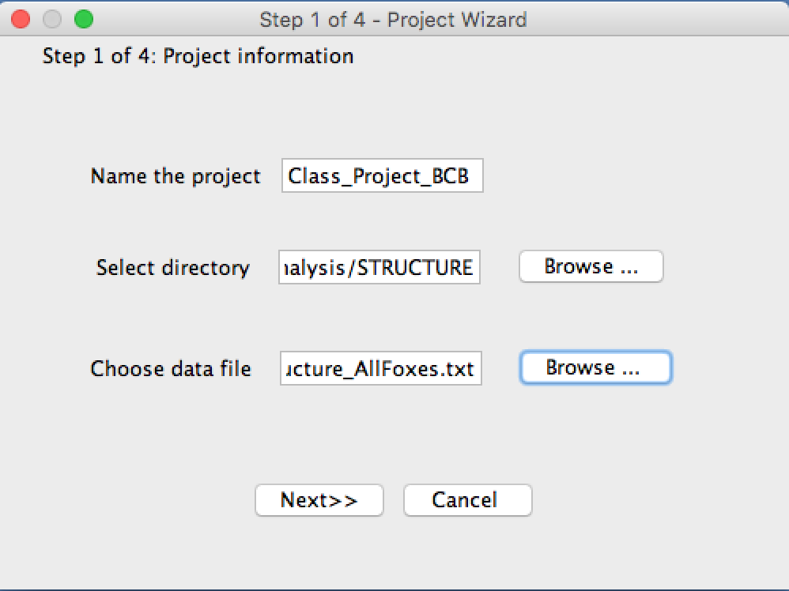

3. Step 2: Fill in the number of individuals, the ploidy of your SNPs (2), the number of SNPs, and the missing data value (in PGDSpyder, the STRUCTURE format output uses -9)

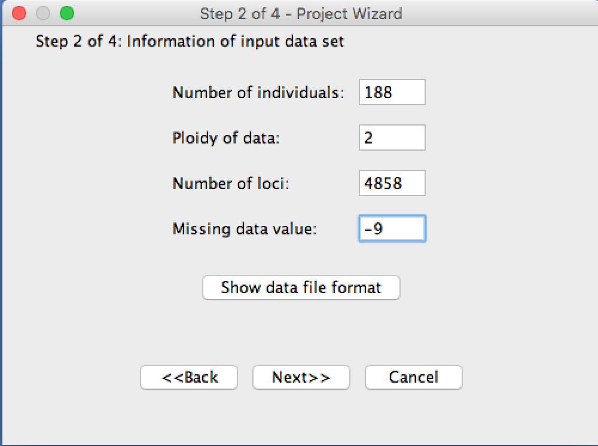

4. Step 3: Indicate that your file has a row of marker names

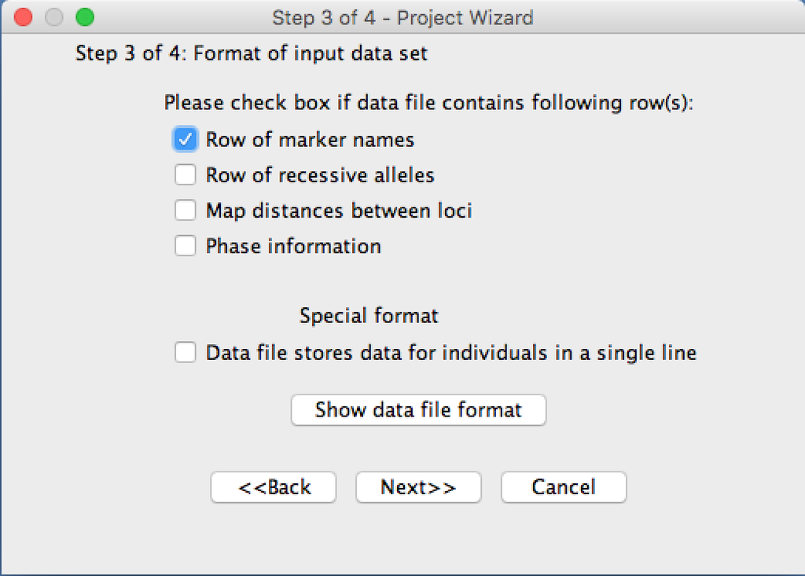

5. Step 4: Indicate that your file has individual ID for each individual, and putative population origin for each individual (since you know which island each fox is from)

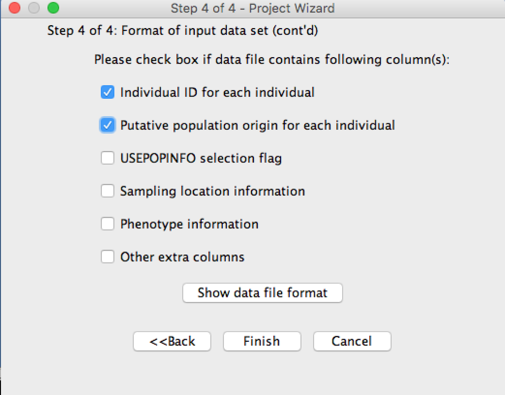

6. Your final settings should look like this:

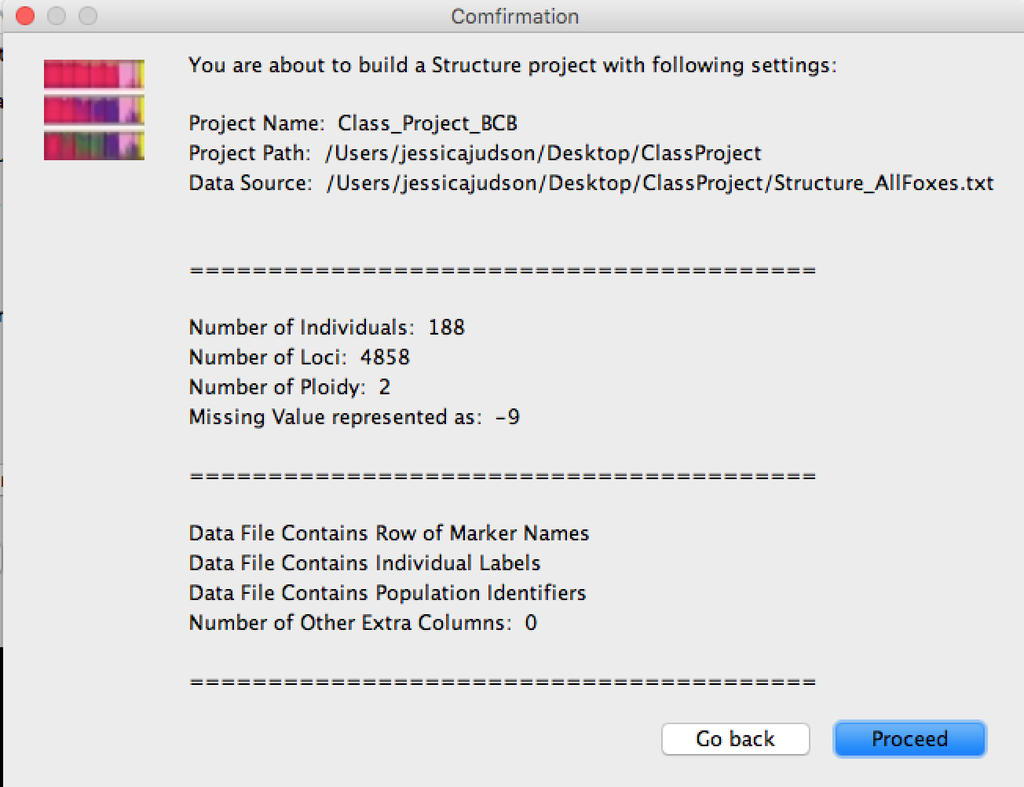

7. Create a new parameter setting for your STRUCTURE run:

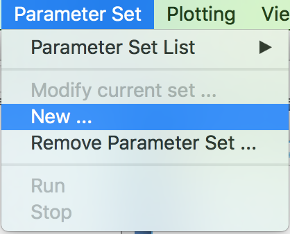

**Original specifications of STRUCTURE run from Funk et al. 2016: MCMC burn-in of 100,000 steps followed by 100,000 steps for inference of clustering, used the admixture model with correlated allele frequencies.** We used a much reduced run to see if we could pull out the same results, with a burn-in of 1000 and 1000 reps after the burn-in, with all other settings the same.

8. Fill in the appropriate burn-in and reps values:

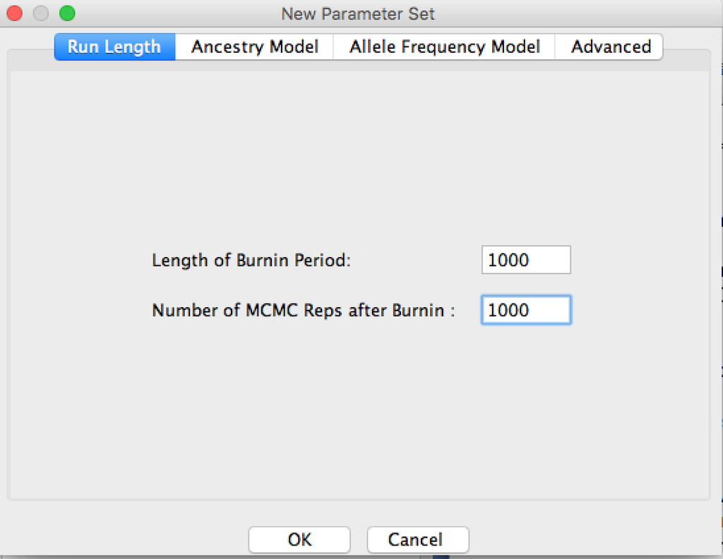

9. Set the Ancestry and Allele settings:

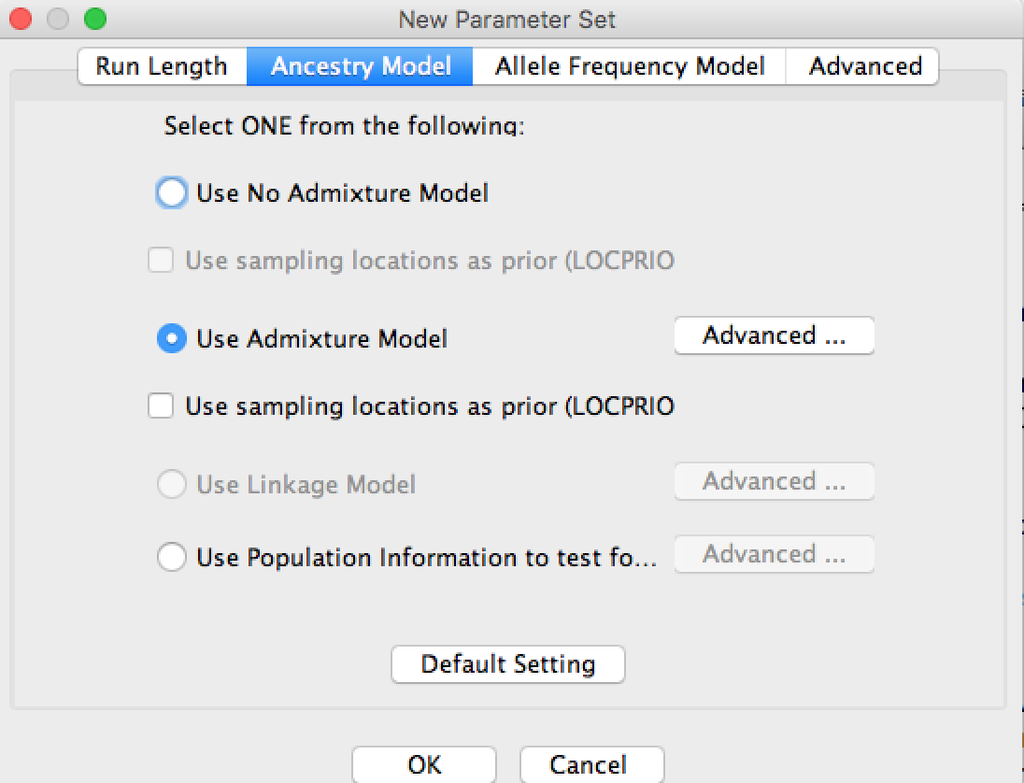

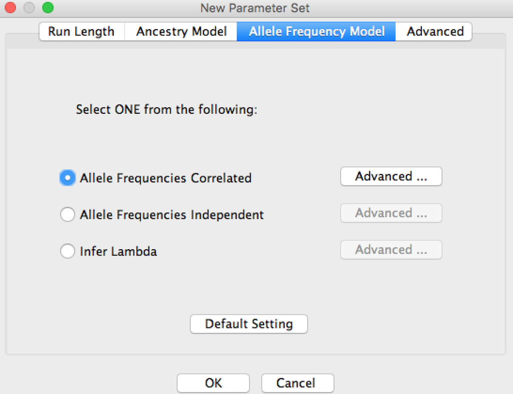

10. Go to the Project tab and choose “Start a job”. Select your created parameter set, and **set the value of K from 1 to 10 with 10 replicates for each value of K, as in Funk et al. 2016**.

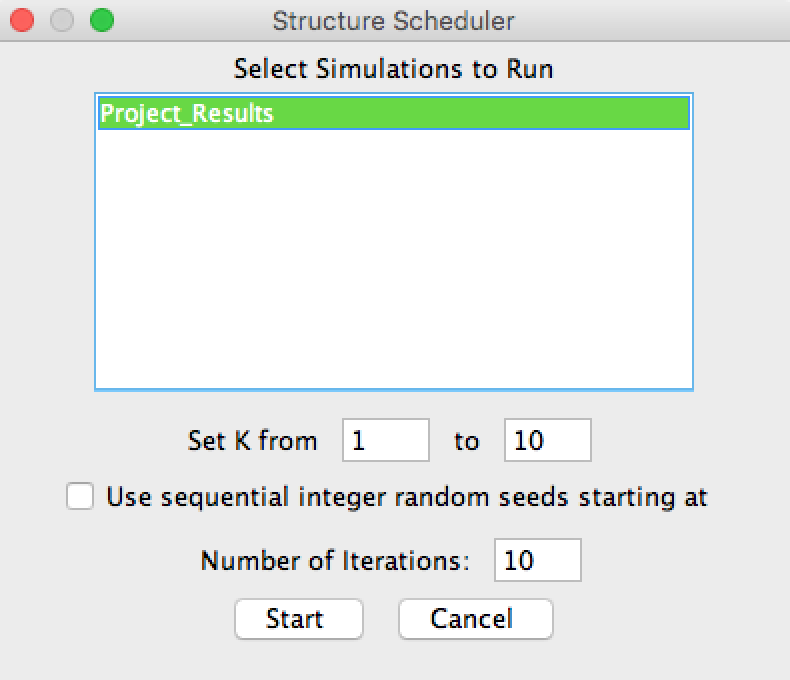

### Results will be placed in your directory that you specified for the project.

## Viewing STRUCTURE plots within STRUCTURE

- Click on the results file on the left-hand side of the screen to see all of the runs for each K. You can view the resulting plots by clicking a specified run, select **Bar Plot** and show. A Bar Plot of one run from K=7 is below:

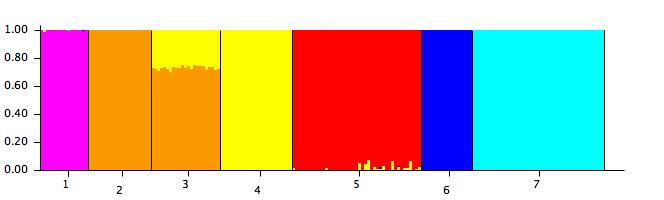